# DiD1 Differential Exposure Difference-in-Differences

ECON 474 Econometrics of Policy Evaluation

This replication is going to focus on the main results of “The Role of High-Skill Labor Demand on Spatial Income Inequality: Evidence from the Dotcom Bubble.” We are going to demonstrate:

1. Creating an event study figure
2. Estimating a differential exposure difference-in-differences with controls
3. Perfomring an arsenal of placebo checks

To get ourselves going, we are going to need a few more packages than normal and then we are going to load in the data as usual.

```r
install.packages('latex2exp')
```

```r
library(tidyverse)
```

```r
library(fixest)
library(stringr)   # String manipulation
library(latex2exp) # putting LaTeX math into our figure labels

df = read_csv('C:/Users/johnj/Dropbox/Julian/Academia/UIUC/Semester 12 Spring 2023/ECON474sp23/Data/DiD2 differential exposure.csv')
head(df)
```

```
## # A tibble: 6 × 8
##   metarea  year q90_q10_tot comp_90 pop_90 ba_share_90 med_house_value…¹ fin_s…²
##     <dbl> <dbl>       <dbl>   <dbl>  <dbl>       <dbl>             <dbl>   <dbl>
## 1       8  1970        8.27    3.68 656736        20.9             67500    2.16
## 2       8  1980        9.11    3.68 656736        20.9             67500    2.16
## 3       8  1990        9.2     3.68 656736        20.9             67500    2.16
## 4       8  2000        8.25    3.68 656736        20.9             67500    2.16
## 5       8  2005        9.39    3.68 656736        20.9             67500    2.16
## 6       8  2006        9.38    3.68 656736        20.9             67500    2.16
## # … with abbreviated variable names ¹med_house_value_90, ²fin_share_90
```

```r
summary(df)
```

```
##     metarea           year       q90_q10_tot        comp_90
##  Min.   :  8.0   Min.   :1970   Min.   : 4.950   Min.   : 1.074
##  1st Qu.:204.0   1st Qu.:2000   1st Qu.: 7.873   1st Qu.: 2.410
##  Median :460.0   Median :2006   Median : 8.807   Median : 3.514
##  Mean   :460.8   Mean   :2001   Mean   : 9.050   Mean   : 4.089
##  3rd Qu.:698.0   3rd Qu.:2009   3rd Qu.: 9.918   3rd Qu.: 4.716
##  Max.   :932.0   Max.   :2011   Max.   :26.643   Max.   :23.969
##      pop_90          ba_share_90    med_house_value_90  fin_share_90
##  Min.   :  104174   Min.   :11.31   Min.   : 32500     Min.   :1.368
##  1st Qu.:  187238   1st Qu.:17.44   1st Qu.: 57500     1st Qu.:2.112
##  Median :  363917   Median :21.73   Median : 67500     Median :2.505
##  Mean   :  813249   Mean   :22.08   Mean   : 83052     Mean   :2.729
##  3rd Qu.:  802311   3rd Qu.:25.25   3rd Qu.: 85000     3rd Qu.:3.149
##  Max.   :15542125   Max.   :44.38   Max.   :275000     Max.   :7.490
```

# 1 Event Study

Constructing the event study figure requires estimating an event study regression. We are somewhat jumping the gun here by running the event study before the main results, but I am confident that life will do its best to be okay.

## 1.1 Event Study Regression

The important part of an event study is that the period $t=0$ (the period just before treatment) is set to be the baseline. What this means when we hop to the computer is that it will be hard coded as zero.

For the regression, we need to create a variable `year_factor` that has class `factor` with the first factor set to `"1990"`. We are going to use the help of the function `fct_relevel()` from the `forcats` package, which is nested in the `tidyverse`.

```r
df = df %>%
  mutate(year_factor = factor(year),
         year_factor = fct_relevel(year_factor, "1990"))
```

It is easy to check if what we did actually worked.

```r
df %>%
  pull(year_factor) %>%
  levels()
```

```
##  [1] "1990" "1970" "1980" "2000" "2005" "2006" "2007" "2008" "2009" "2010"
## [11] "2011"
```

Excellent! Now the next step is to estimate the event study regression.

```r
fit_event = feols(q90_q10_tot ~ year_factor*log(comp_90) +
                    log(pop_90) + ba_share_90 + log(med_house_value_90),
                  data = df,
                  se = 'hetero')
etable(fit_event)
```

```
##                                         fit_event
## Dependent Var.:                       q90_q10_tot
##
## Constant                         7.072*** (1.541)
## year_factor1970                  -0.6293 (0.4472)
## year_factor1980                  -0.2668 (0.3201)
## year_factor2000                -1.320*** (0.3460)
## year_factor2005                   0.1763 (0.4123)
## year_factor2006                  -0.0736 (0.4412)
## year_factor2007                  -0.4347 (0.4114)
## year_factor2008                  -0.2185 (0.4235)
## year_factor2009                  -0.4373 (0.4074)
## year_factor2010                   0.5256 (0.4343)
## year_factor2011                   0.5340 (0.4325)
## log(comp_90)                   -1.008*** (0.1974)
## log(pop_90)                    -0.1699** (0.0627)
## ba_share_90                    0.1369*** (0.0100)
## log(med_house_value_90)           0.1550 (0.1790)
## year_factor1970 x log(comp_90)    0.1300 (0.3052)
## year_factor1980 x log(comp_90)    0.2458 (0.2422)
## year_factor2000 x log(comp_90)  0.7651** (0.2886)
## year_factor2005 x log(comp_90)   0.6172. (0.3167)
## year_factor2006 x log(comp_90)   0.7594* (0.3337)
## year_factor2007 x log(comp_90)   1.059** (0.3271)
## year_factor2008 x log(comp_90)  0.9038** (0.3357)
## year_factor2009 x log(comp_90)  1.088*** (0.3232)
## year_factor2010 x log(comp_90)   0.8036* (0.3458)
## year_factor2011 x log(comp_90)  0.9588** (0.3457)
## ______________________________ __________________
## S.E. type                      Heteroskedas.-rob.
## Observations                                2,015
## R2                                        0.29364
## Adj. R2                                   0.28513
## ---
## Signif. codes: 0 '***' 0.001 '**' 0.01 '*' 0.05 '.' 0.1 ' ' 1
```

The next step is to grab the coefficients that correspond to `year_factorXXXX x log(comp_90)` and the respective 95% confidence interval to produce our figure.

## 1.2 Event Study Figure

I should point out that the package `fixest` has a function `coefplot()` that plots coefficients with the respective 95% confidence interval, but this function doesn’t quite work here. Within `coefplot()` it is possible to select the coefficients you want, which could be useful for a different application. However, as far as I am aware it is not possible to hard code in a coefficient for 1990 that is zero. Even if that was possible, the coefficients we want are at both a decade and annual interval, so we will have to construct the figure manually.

Then end goal is to have a `data.frame` that has

- coefficient estimates
- coefficient 95% confidence interval upper and lower bound
- the corresponding year

To construct this `data.frame` for plotting, we are going to use a regular expression (there are tons of resources available online if you are curious about how to use these in your own work). Specifically, we will use `str_detect()` and later `str_extract()` from the `stringr` package.

```r
# coef(fit_event)
# confint(fit_event, se = 'hetero')
# bind_cols(coef(fit_event),
#           confint(fit_event, se = 'hetero'))%>%
#   rename(delta_k = `...1`)

df_event = bind_cols(coef(fit_event),
          confint(fit_event, se = 'hetero')) %>%
  rename(delta_k = `...1`)
# row.names(df_event)
# str_detect(row.names(df_event), "[year_factor][0-9]{4}[:]")
df_event = df_event %>%
  filter(str_detect(row.names(df_event), "[year_factor][0-9]{4}[:]"))

as.numeric(str_extract(row.names(df_event), '[0-9]{4}'))
```

```
##  [1] 1970 1980 2000 2005 2006 2007 2008 2009 2010 2011
```

```r
df_event$year = as.numeric(str_extract(row.names(df_event), '[0-9]{4}'))
```

The regular expression we just wrote returns `TRUE` for strings that match a string that

1. `[year_factor]` has the exact string `"year_factor"`
2. `[0-9]{4}` that is followed by exactly four digits
3. `[:]` which is then followed by a colon

Now we can use the names of the vector we just created to extract the year. Since we are at it, we might as well add the zero values for 1990. We are going to use base R’s `rbind()` function, which binds rows ignoring column names unlike `dplyr::bind_rows()`.

```r
# adding omitted "base" year
df_event = rbind(df_event, c(0, 0, 0, 1990)) %>%
  arrange(year)
df_event
```

```
##                                delta_k        2.5 %    97.5 % year
## year_factor1970:log(comp_90) 0.1300039 -0.468619439 0.7286273 1970
## year_factor1980:log(comp_90) 0.2458155 -0.229199666 0.7208307 1980
## 11                           0.0000000  0.000000000 0.0000000 1990
## year_factor2000:log(comp_90) 0.7650584  0.199150647 1.3309662 2000
## year_factor2005:log(comp_90) 0.6172073 -0.003971734 1.2383863 2005
## year_factor2006:log(comp_90) 0.7593522  0.104975675 1.4137286 2006
## year_factor2007:log(comp_90) 1.0587467  0.417171440 1.7003219 2007
## year_factor2008:log(comp_90) 0.9037627  0.245455692 1.5620697 2008
## year_factor2009:log(comp_90) 1.0883330  0.454530804 1.7221353 2009
## year_factor2010:log(comp_90) 0.8035842  0.125413243 1.4817552 2010
## year_factor2011:log(comp_90) 0.9587811  0.280896441 1.6366657 2011
```

Because event study figures are the most important figure in difference-in-differences, I am going to show you how to make a presentation quality figure. We can put math into the figure labs using the `TeX()` function from the `latex2exp` package. Note, however, that it requires using double `\\` because the R strings are looking for things like `"\n"`. The double backslash says “no, I really want a backslash here.”

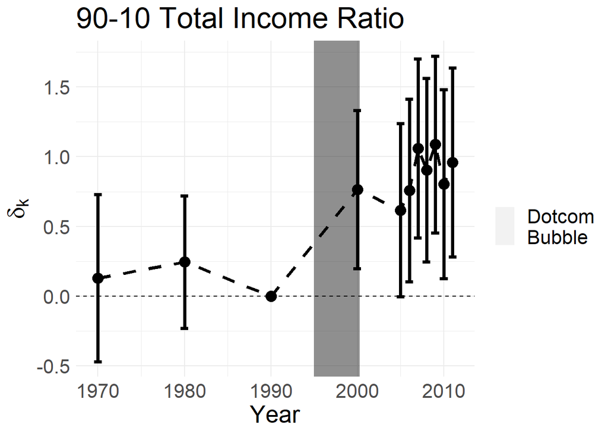

```r
ggplot(df_event, aes(x = year, y = delta_k, ymin = `2.5 %`, ymax = `97.5 %`)) +
  geom_point(size = 4) +
  geom_line(linetype = 'dashed', size = 1.4) +
  geom_errorbar(size = 1.4) +
  geom_hline(yintercept = 0, linetype = 'dashed') +
  geom_rect(xmin = 1995, xmax = 2000.25, ymin = -Inf, ymax = Inf,
            alpha = 0.05, aes(fill = 'Dotcom\nBubble')) +
  scale_fill_manual(values = 'black') +
  labs(x = 'Year', y = TeX('$\\delta_k$'),
       title = '90-10 Total Income Ratio',
       fill = '') +
  theme_minimal()  +
  theme(text = element_text(size = 20)) # must go after plot appearance theme
```

# 2 Main Result

Recall that the main regressions use only data from 1990 and 2000 to only use information from the Dotcom period. To save ourselves from making mistakes, we will create a regression specific data from. We will also use this data to create a new variable `post` to indicate being in the post treatment period(s).

```r
df_reg = df %>%
  filter(year %in% c(1990, 2000)) %>%
  mutate(post = (year >= 2000)*1)
```

Time to run the differential exposure difference-in-differences!

```r
fit_main = feols(q90_q10_tot ~ post*log(comp_90) +
                    log(pop_90) + ba_share_90 + log(med_house_value_90),
                  data = df_reg,
                  se = 'hetero')

etable(fit_main, se.below = TRUE)
```

```
##                            fit_main
## Dependent Var.:         q90_q10_tot
##
## Constant                 12.59***
##                          (3.229)
## post                     -1.320***
##                          (0.3403)
## log(comp_90)             -0.6862**
##                          (0.2273)
## log(pop_90)              -0.1201
##                          (0.1371)
## ba_share_90               0.1098***
##                          (0.0189)
## log(med_house_value_90)  -0.3765
##                          (0.3984)
## post x log(comp_90)       0.7651**
##                          (0.2916)
## _______________________ ___________
## S.E. type               Heter.-rob.
## Observations                    382
## R2                          0.17511
## Adj. R2                     0.16191
## ---
## Signif. codes: 0 '***' 0.001 '**' 0.01 '*' 0.05 '.' 0.1 ' ' 1
```

The main result says that a 1% increase in exposure to the Dotcom bubble increased the 90-10 ratio by about 0.77. To find out, let’s take a look at the average pre-treatment level of income inequality.

```r
pre_90_10 = df_reg %>%
  filter(year == 1990) %>%
  pull(q90_q10_tot) %>%
  mean

coef(fit_main)[7]/pre_90_10
```

```
## post:log(comp_90)
##         0.0914836
```

This tells us that a 1% increase in exposure to the Dotcom bubble increased the 90-10 ratio by 9% for the average MSA.

# 3 Placebo Checks

We are going to run three robustness checks to determine if we have any confounders, if the results are only being driven by silicon valley, and to provide more evidence for parallel trends.

## 3.1 Fincial-related employment exposure placebo

One of the main threats to identification comes from the nature of the Dotcom bubble; it was a stock market bubble. The results could simply be driven from MSAs with high level of pre-period computer-related employment are highly correlated with finance-related employment. It could be the case that the growth in income inequality is purely due to returns on investment. We can check this by using finance employment as a placebo.

```r
feols(q90_q10_tot ~ post*log(fin_share_90) +
                    log(pop_90) + ba_share_90 + log(med_house_value_90),
                  data = df_reg,
                  se = 'hetero') %>%
  etable(se.below = TRUE)
```

```
##                                    .
## Dependent Var.:          q90_q10_tot
##
## Constant                  12.21***
##                           (2.395)
## post                      -1.566*
##                           (0.7241)
## log(fin_share_90)         -1.291***
##                           (0.3106)
## log(pop_90)               -0.0632
##                           (0.1852)
## ba_share_90                0.1072***
##                           (0.0164)
## log(med_house_value_90)   -0.3714
##                           (0.3309)
## post x log(fin_share_90)   1.275
##                           (0.8067)
## ________________________ ___________
## S.E. type                Heter.-rob.
## Observations                     382
## R2                           0.17860
## Adj. R2                      0.16545
## ---
## Signif. codes: 0 '***' 0.001 '**' 0.01 '*' 0.05 '.' 0.1 ' ' 1
```

## 3.2 Is Silicon Valley driving the results?

The U.S. has a pretty strong narrative that Silicon Valley is where everything computers happens. The distribution of the exposure variable also shows that the San Jose MSA is an outlier in exposure. It is natural to ask if that MSA is the reason for significance. Fortunately, it is incredibly easy to check this. Simply remove the San Jose MSA from the regression.

To figure out which code corresponds to the San Jose MSA, let’s look at the documentation for the [`METAREA`](https://usa.ipums.org/usa-action/variables/METAREA#codes_section) variable.

```r
feols(q90_q10_tot ~ post*log(comp_90) +
                    log(pop_90) + ba_share_90 + log(med_house_value_90),
                  data = df_reg,
                  se = 'hetero',
      subset = df_reg$metarea != 740) %>%
  etable(fit_main, se.below = TRUE)
```

```
##                                   .    fit_main
## Dependent Var.:         q90_q10_tot q90_q10_tot
##
## Constant                 13.07***    12.59***
##                          (3.368)     (3.229)
## post                     -1.277***   -1.320***
##                          (0.3512)    (0.3403)
## log(comp_90)             -0.7158**   -0.6862**
##                          (0.2322)    (0.2273)
## log(pop_90)              -0.1176     -0.1201
##                          (0.1384)    (0.1371)
## ba_share_90               0.1105***   0.1098***
##                          (0.0188)    (0.0189)
## log(med_house_value_90)  -0.4208     -0.3765
##                          (0.4130)    (0.3984)
## post x log(comp_90)       0.7271*     0.7651**
##                          (0.3050)    (0.2916)
## _______________________ ___________ ___________
## S.E. type               Heter.-rob. Heter.-rob.
## Observations                    380         382
## R2                          0.17409     0.17511
## Adj. R2                     0.16081     0.16191
## ---
## Signif. codes: 0 '***' 0.001 '**' 0.01 '*' 0.05 '.' 0.1 ' ' 1
```

Some statistical significance is lost, but the estimate wihtout San Jose is still signficant and the two coefficients are not statistically distinguishable.

## 3.3 Lagged Outcome

The final robustness check we will do is to provide show that we are not simply picking up on a spurious trend, which provides some evidence in support of parallel trends. We will need to go back to the full data to demonstrate this.

```r
df_reg_lag = df %>%
  arrange(metarea, year) %>%
  group_by(metarea) %>%
  mutate(q90_q10_tot_lag = lag(q90_q10_tot),
         post = (year >= 2000)*1) %>%
  filter(year %in% c(1990, 2000))

feols(q90_q10_tot_lag ~ post*log(comp_90) +
                    log(pop_90) + ba_share_90 + log(med_house_value_90),
                  data = df_reg_lag,
                  se = 'hetero') %>%
  etable(se.below = TRUE)
```

```
##                                       .
## Dependent Var.:         q90_q10_tot_lag
##
## Constant                     16.74***
##                              (2.103)
## post                          0.2668
##                              (0.3023)
## log(comp_90)                 -0.2055
##                              (0.1646)
## log(pop_90)                  -0.0058
##                              (0.0615)
## ba_share_90                   0.0894***
##                              (0.0115)
## log(med_house_value_90)      -0.8881***
##                              (0.2101)
## post x log(comp_90)          -0.2458
##                              (0.2351)
## _______________________ _______________
## S.E. type               Heteroske.-rob.
## Observations                        382
## R2                              0.17006
## Adj. R2                         0.15679
## ---
## Signif. codes: 0 '***' 0.001 '**' 0.01 '*' 0.05 '.' 0.1 ' ' 1
```

Seems like we are not picking up on a spurious trend in the data!

# 4 Concluding Comments

Regardless if you are doing a traditional diff-in-diff or a differential exposure diff-in-diff, everything that we have done in this lecture are essential to supporting the empirical design. Being able to plot an event study figure is just as crucial as using placebos to rule out confounders, outliers, and spurious correlations. These checks should be done with every analysis. Moreover, placebo checks should also be used regardless of the technique you use (instrumental variables, regression discontinuity, etc.) to support your claims.